# Is the Phillips Curve dead for all?

Pritha Chaudhuri

6/2/2020

## Aggregate Phillips Curve: Data

Available measures of inflation and inflation expectations

- Consumer Price Index (CPI), BLS measure
- Personal Consumption Expenditure (PCE), BEA measure
- GDP Deflator
- Greenbook forecasts
- FOMC Member forecasts
- Michigan Survey of Consumers, household expectations of inflation

Measure of unemployment

- BLS measure
- Greenbook forecast
- FOMC member forecasts

### CPI, PCE and BLS measure of unemployment

Monthly inflation is calculated as
$$\pi_t=1200\times(\log(P_t)-log(P_{t-1}))$$
where $P_t$ is a price index (CPI or PCE) in month $t$. Quarterly averages of monthly inflation and unemployment are then calculated.

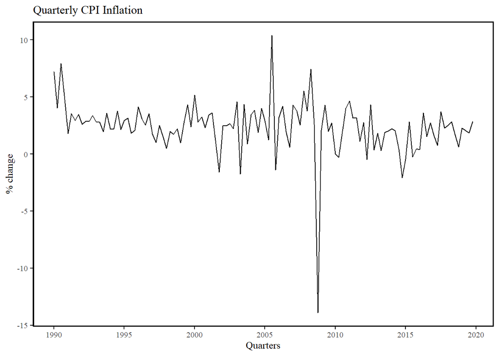

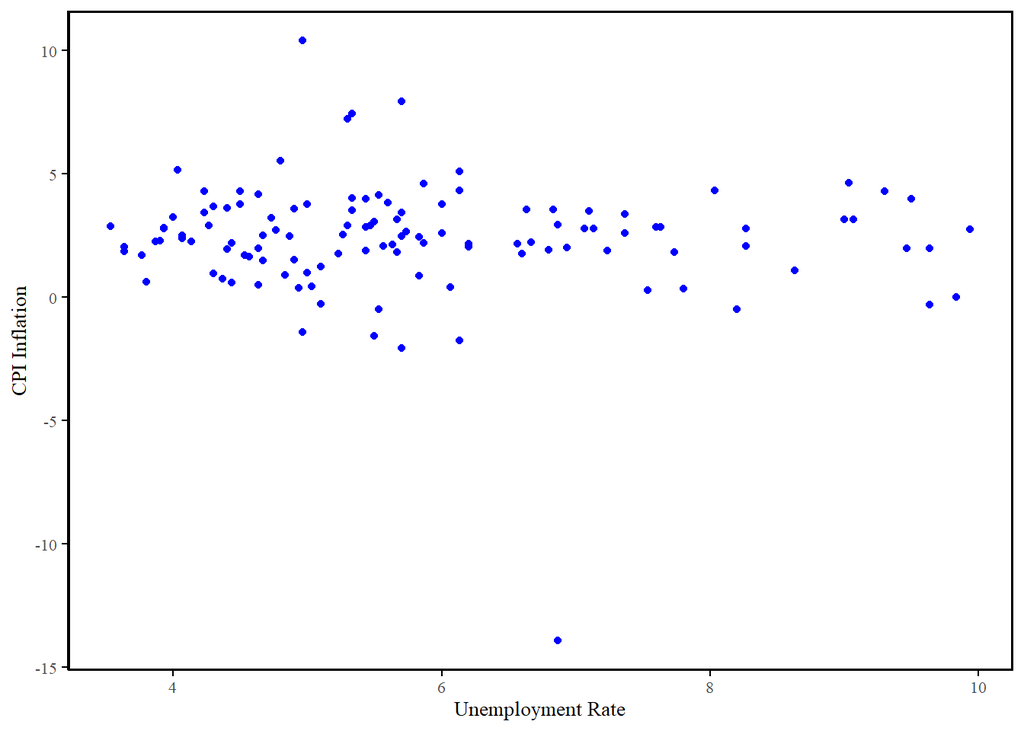

### Greenbook Forecasts

Greenbook projections are made available to the FOMC before each meeting. The Fed research staff makes projections of how the economy will fare in the future. The data is made available to the public with a 5 year lag. Most current year of data is 2013.

Each year there are approximately 8 FOMC meetings and hence 8 sets of Greenbook forecasts that are released each year. So for each quarter there are 2 forecasts available and I use the mean of the 2 forecasts.

Specifically, the variables of interest from each Greenbook are

- gPCPIXF0: inflation forecast for current quarter
- gPCPIXB1: historical value of inflation for previous quarter
- UNEMPF0: unemployment forecast for current quarter

The inflation measure for current quarter $t$ is the mean of PCPIXF0 for the two forecasts released that quarter. For example, 1990:Q1 had FOMC meetings in February and March. Then the inflation measure for 1990:Q1 is

$$\pi_{1990:Q1} = \frac{1}{2}\Big( gPCPIXF0_{1990:Feb}+gPCPIXF0_{1990:March} \Big)$$
Simialrly, for expected inflation and unemployment rate.

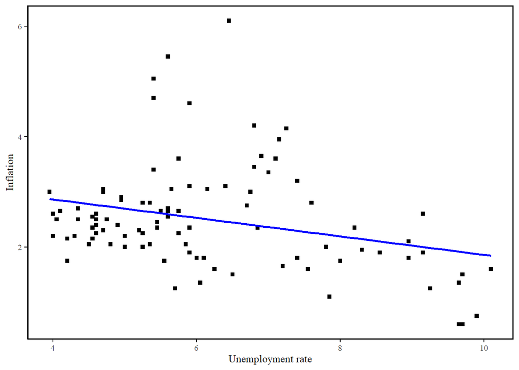

## Aggregate Phillips Curve: Estimation

Estimate the following Phillips Curve
$$\pi_t=\alpha+\beta\pi_{t-1}+\gamma u_t+\varepsilon_t$$
where $\pi_t$ is inflation in current quarter $t$ and $\pi_{t-1}$ is inflation in previous quarter.

### Greenbook Forecasts

#### Estimation results

Estimate PC for 1990-2013. Results of estimation and plot of fitted values.

```
##
## Call:
## tslm(formula = qPCPIXF0 ~ qPCPIXB1 + qUNEMP, data = tsgbdata)
##
## Residuals:
##      Min       1Q   Median       3Q      Max
## -1.73040 -0.34530 -0.02443  0.29343  2.63928
##
## Coefficients:
##             Estimate Std. Error t value Pr(>|t|)
## (Intercept)  1.39369    0.30878   4.514 1.86e-05 ***
## qPCPIXB1     0.63533    0.05703  11.140  < 2e-16 ***
## qUNEMP      -0.07846    0.03884  -2.020   0.0462 *
## ---
## Signif. codes:  0 '***' 0.001 '**' 0.01 '*' 0.05 '.' 0.1 ' ' 1
##
## Residual standard error: 0.6025 on 93 degrees of freedom
## Multiple R-squared:  0.6068, Adjusted R-squared:  0.5984
## F-statistic: 71.77 on 2 and 93 DF,  p-value: < 2.2e-16
```

#### Actual vs Fitted values

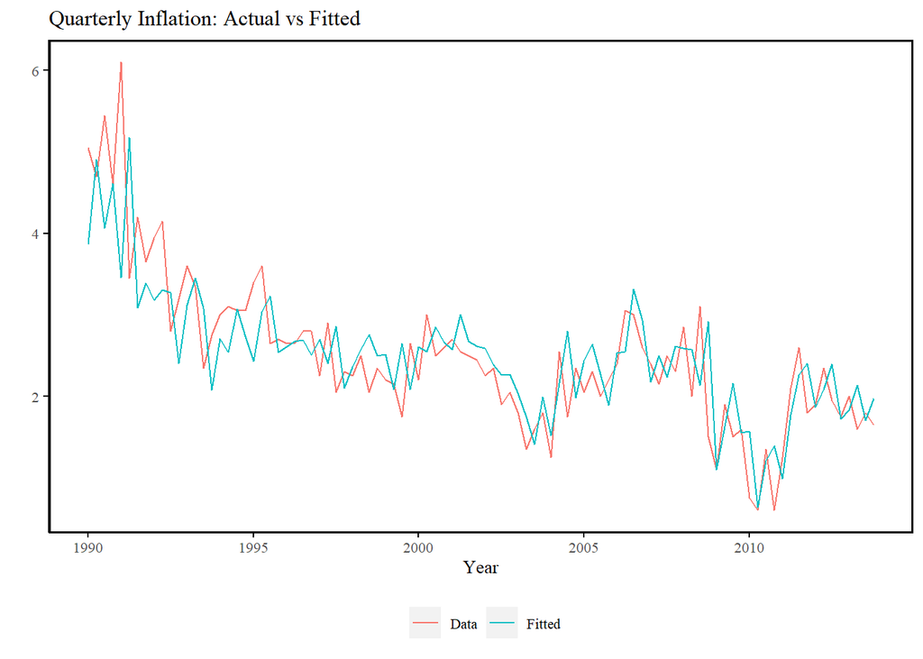

#### Forecast

Forecasting 2014-2019 (24 quarters) inflation using above model. Compare with actual inflation for 2014-2019 and calculate RMSE.

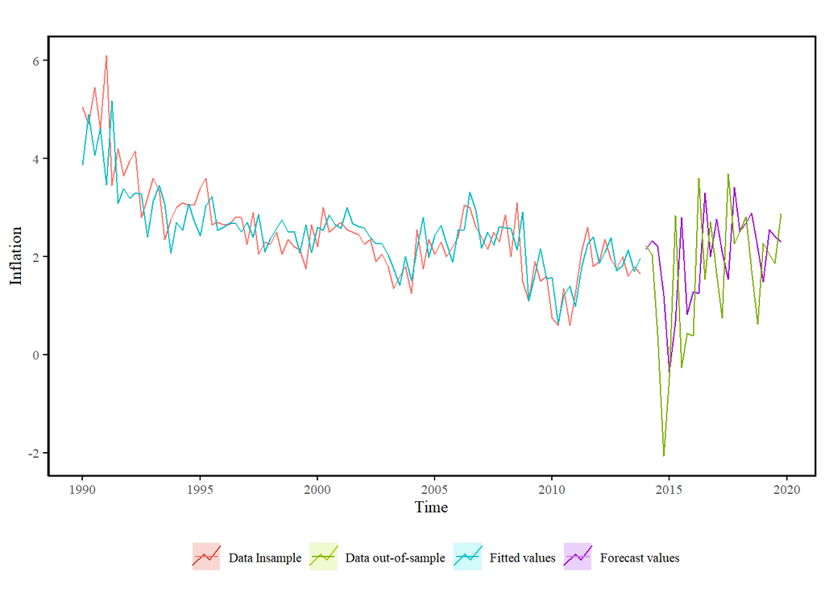

#### RMSE of forecast

```
## [1] 0.4166268
```

## Disaggregate Phillips Curve: Data

Above exercise so far has been considering the entire economy and the aggregate unemployment rate. But what about different subgroups of the labor market? Will the Phillips curve relationship hold for one subgroup and not for the other? Different subgroups that can be considered are

- Education: high-skill vs low-skill
- Gender: male vs female
- Race: White vs Black
- Age: Young vs Old

We can estimate Phillips curves for the different sugroups and combine them to get the aggregate Phillips curve for the economy. This accounts for any variation there might be in the inflation-unemployment relationship by subgroups.

To calculate unemployment numbers I use the CPS MORG files from 1979-2018.

### Education Levels

The four different categories considered are

1. Bachelor’s degree or higher
2. Some college or Associate’s degree
3. High-school graduates, no college
4. Less than high-school diploma

Using these 4 categories of education and combining them with Greenbook forecasts for inflation. The CPS data is available starting at 1979. Even though Greenbooks have been published since 1967, the full range of inflation forecasts arent available until 1986, which is where I start. Greenbook forecasts end in 2013.

#### qBachelors

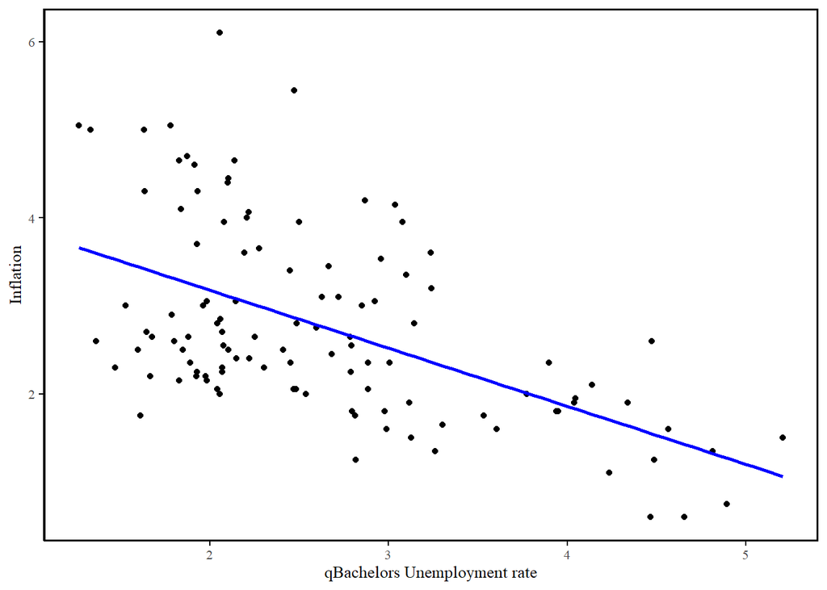

#### qSomecoll

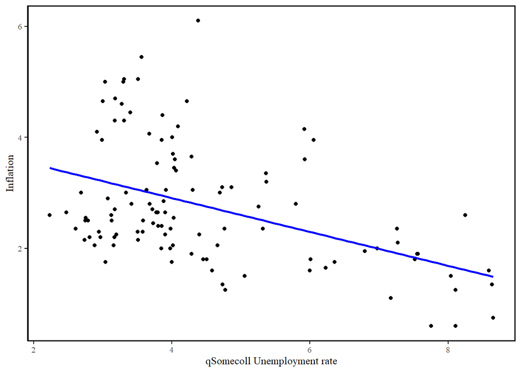

#### qHSgrad

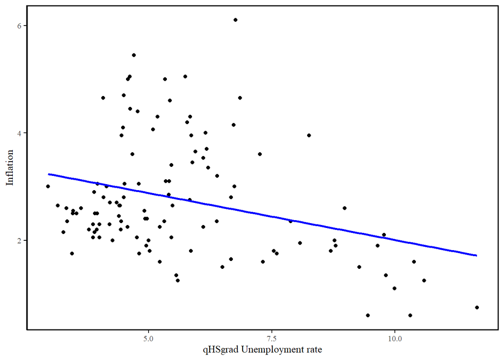

#### qLessHS

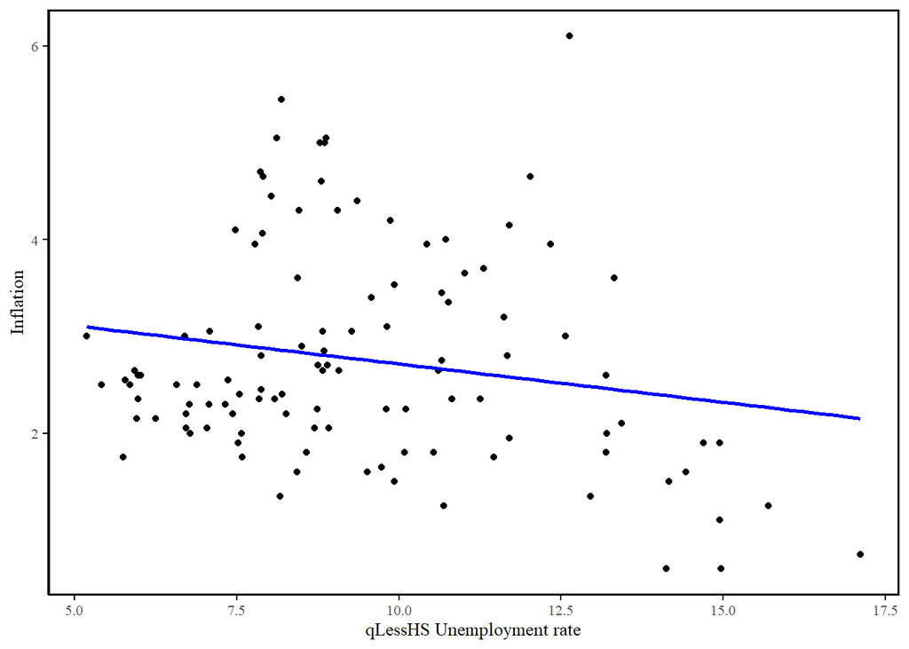

### Gender

#### qMen

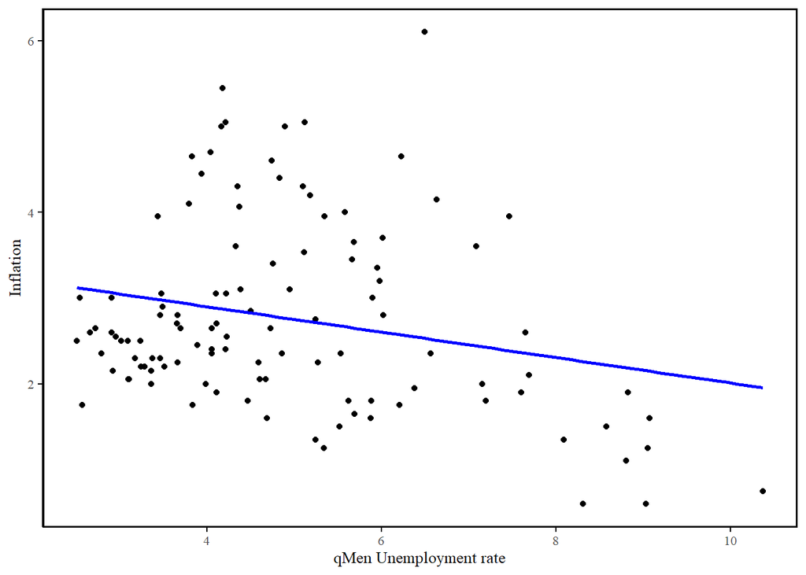

#### qWomen

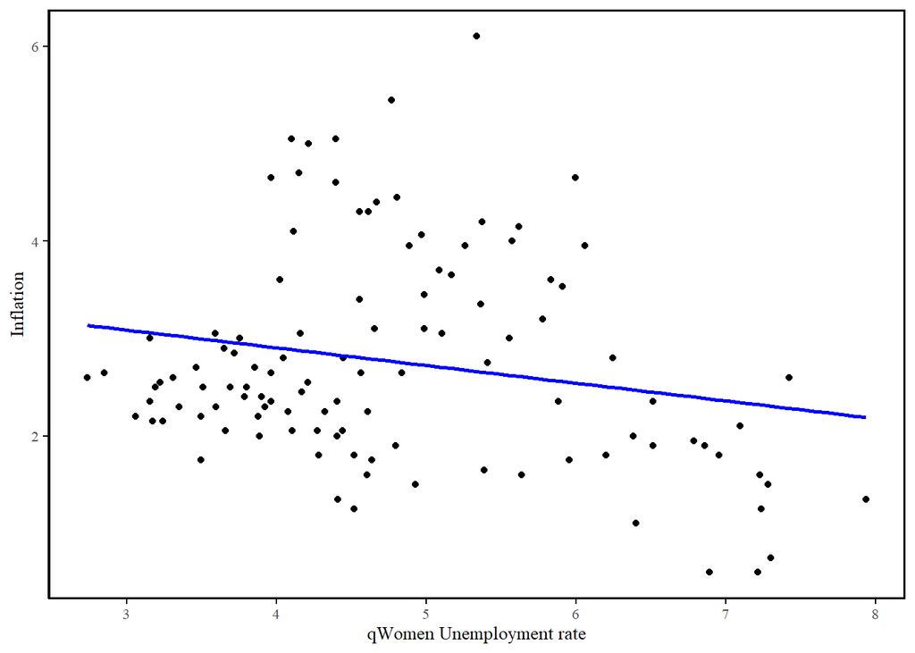

## Disaggregate Phillips Curve: Estimation

Estimate the following Phillips Curve

$$\pi_t=\alpha+\beta\pi_{t-1}+\gamma u^s_t+\varepsilon_t$$

where $\pi_t$ is inflation in current quarter $t$ and $\pi_{t-1}$ is inflation in previous quarter. $u^s_t$ is the unemployment rate of the subgroup $s$.

### Education

#### Bachelors

**Parameter Estimates**

```
##
## Call:
## tslm(formula = form, data = data)
##
## Residuals:
##      Min       1Q   Median       3Q      Max
## -1.98543 -0.34510 -0.02861  0.37236  2.32252
##
## Coefficients:
##             Estimate Std. Error t value Pr(>|t|)
## (Intercept)  1.64995    0.27671   5.963 3.12e-08 ***
## qPCPIXB1     0.66320    0.05069  13.083  < 2e-16 ***
## qBachelors  -0.27174    0.06830  -3.978 0.000125 ***
## ---
## Signif. codes:  0 '***' 0.001 '**' 0.01 '*' 0.05 '.' 0.1 ' ' 1
##
## Residual standard error: 0.5833 on 109 degrees of freedom
## Multiple R-squared:  0.7239, Adjusted R-squared:  0.7188
## F-statistic: 142.9 on 2 and 109 DF,  p-value: < 2.2e-16
```

Coefficient estimate on unemployment shows PC is negative with slope of 0.27, significant at the 0.1% level.

**Actual vs Fitted Values**

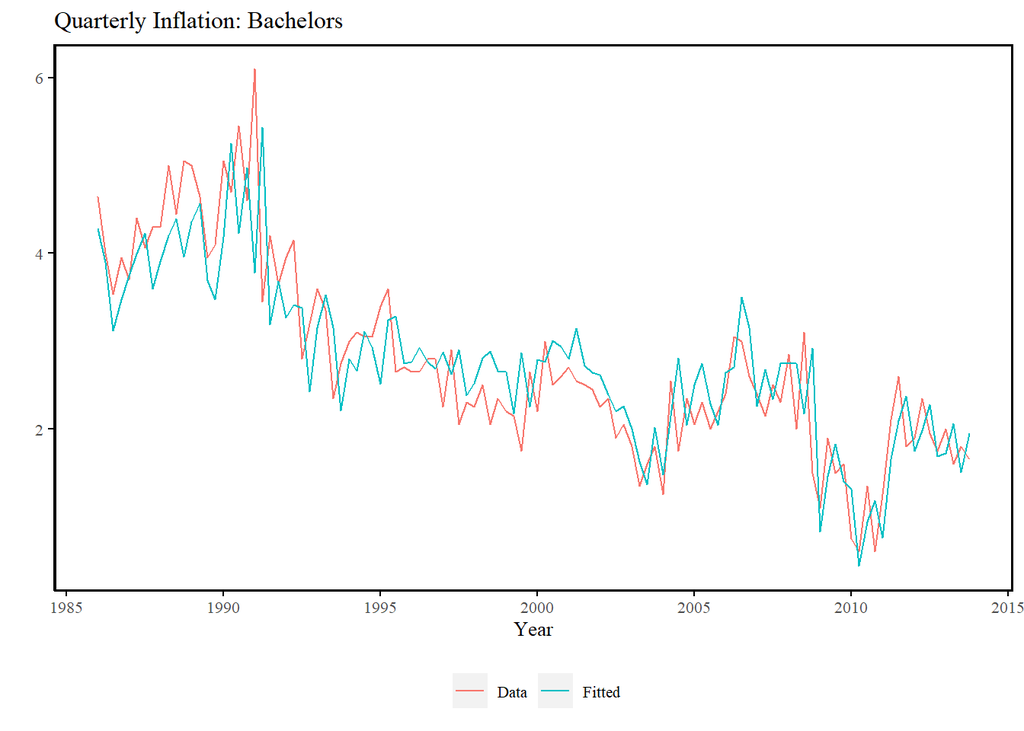

**Inflation Forecast**

Forecasting 2014-2018 (20 quarters) inflation using above model. Compare with actual inflation for 2014-2018 and calculate RMSE.

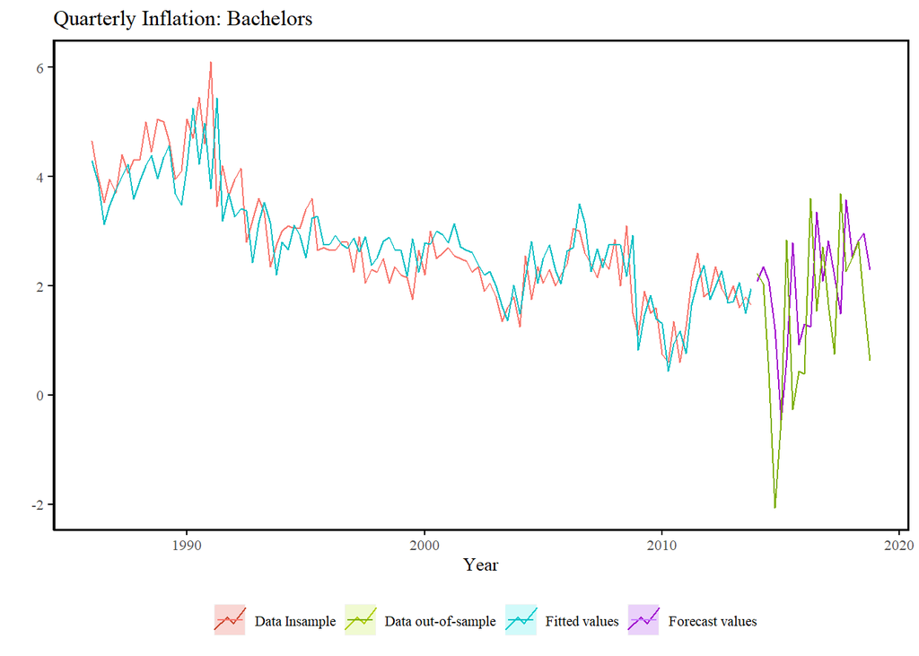

**Root mean squared error** for the forecast is

```
## [1] 0.5433373
```

#### Some College

**Parameter Estimates**

```
##
## Call:
## tslm(formula = form, data = data)
##
## Residuals:
##      Min       1Q   Median       3Q      Max
## -2.18231 -0.39498  0.04555  0.35646  2.42375
##
## Coefficients:
##             Estimate Std. Error t value Pr(>|t|)
## (Intercept)  1.27258    0.27070   4.701 7.62e-06 ***
## qPCPIXB1     0.69891    0.05178  13.497  < 2e-16 ***
## qSomecoll   -0.09745    0.03875  -2.515   0.0134 *
## ---
## Signif. codes:  0 '***' 0.001 '**' 0.01 '*' 0.05 '.' 0.1 ' ' 1
##
## Residual standard error: 0.6068 on 109 degrees of freedom
## Multiple R-squared:  0.7011, Adjusted R-squared:  0.6956
## F-statistic: 127.8 on 2 and 109 DF,  p-value: < 2.2e-16
```

Slope of Phillips Curve is -0.097, flatter than the Bachelor’s group, and significant at the 5% level.

**Actual vs Fitted Values and Forecast**

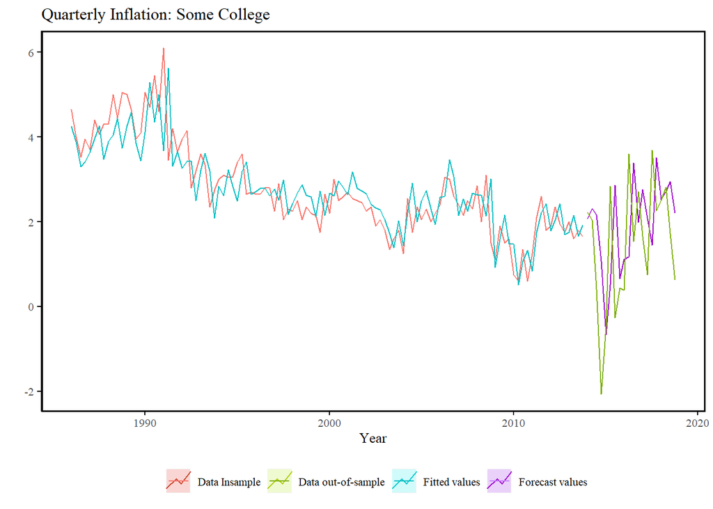

**Root mean squared error** for the forecast is

```
## [1] 0.4710797
```

#### High school graduate, no college

```
##
## Call:
## tslm(formula = form, data = data)
##
## Residuals:
##      Min       1Q   Median       3Q      Max
## -2.24989 -0.37116 -0.00104  0.36479  2.44850
##
## Coefficients:
##             Estimate Std. Error t value Pr(>|t|)
## (Intercept)  1.03771    0.26088   3.978 0.000126 ***
## qPCPIXB1     0.72898    0.05022  14.515  < 2e-16 ***
## qHSgrad     -0.05005    0.03158  -1.585 0.115897
## ---
## Signif. codes:  0 '***' 0.001 '**' 0.01 '*' 0.05 '.' 0.1 ' ' 1
##
## Residual standard error: 0.6171 on 109 degrees of freedom
## Multiple R-squared:  0.6909, Adjusted R-squared:  0.6852
## F-statistic: 121.8 on 2 and 109 DF,  p-value: < 2.2e-16
```

Even though the slope is negative, the parameter estimate is insignificant. This implies unemployment levels of high-school graduates do not respond to inflation.

**Actual vs Fitted values and Forecast**

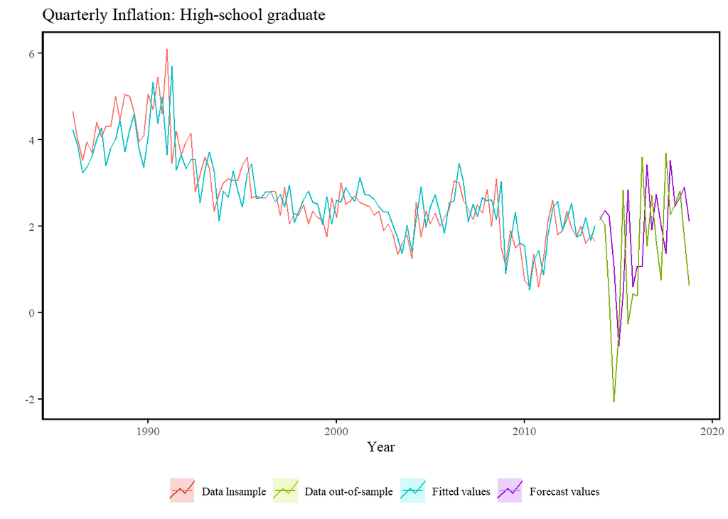

**Root mean squared error** for the forecast is

```
## [1] 0.440501
```

#### Less than HS

**Parameter Estimates**

```
##
## Call:
## tslm(formula = form, data = data)
##
## Residuals:
##      Min       1Q   Median       3Q      Max
## -2.29873 -0.37152  0.00871  0.33868  2.43220
##
## Coefficients:
##             Estimate Std. Error t value Pr(>|t|)
## (Intercept)  0.88235    0.28340   3.113  0.00236 **
## qPCPIXB1     0.74384    0.04953  15.019  < 2e-16 ***
## qLessHS     -0.01798    0.02320  -0.775  0.43999
## ---
## Signif. codes:  0 '***' 0.001 '**' 0.01 '*' 0.05 '.' 0.1 ' ' 1
##
## Residual standard error: 0.6225 on 109 degrees of freedom
## Multiple R-squared:  0.6855, Adjusted R-squared:  0.6797
## F-statistic: 118.8 on 2 and 109 DF,  p-value: < 2.2e-16
```

Once again the slope is negative but the parameter estimate is insignificant. Unemployment levels for people with less than high-school degree also do not respond to inflation.

**Actual vs Fitted values and Forecast**

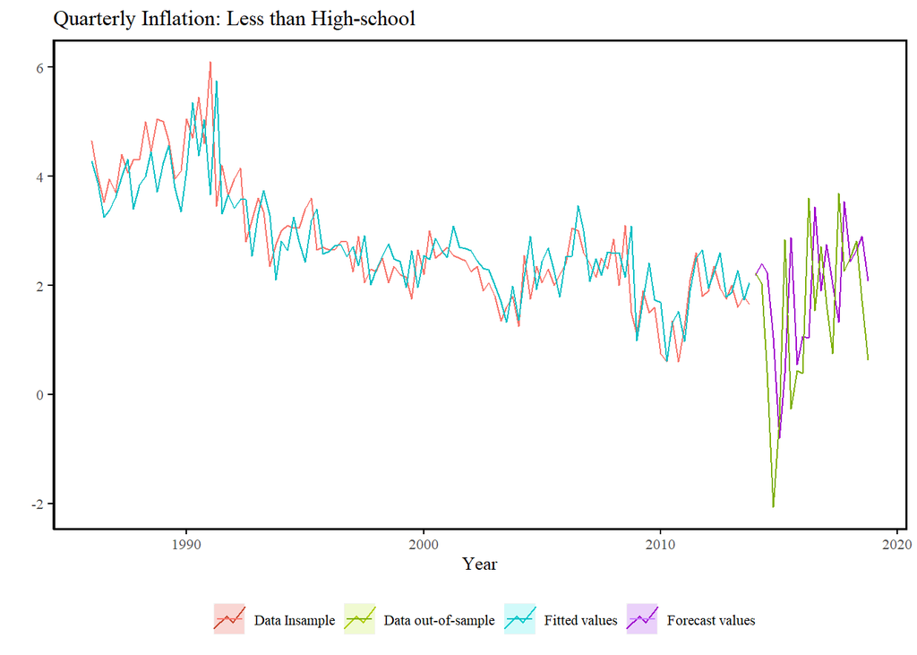

**Root mean squared error** for the forecast is

```
## [1] 0.4280681
```

### Gender

#### Men

**Parameter Estimates**

```
##
## Call:
## tslm(formula = form, data = data)
##
## Residuals:
##      Min       1Q   Median       3Q      Max
## -2.27085 -0.36987  0.00893  0.33212  2.44397
##
## Coefficients:
##             Estimate Std. Error t value Pr(>|t|)
## (Intercept)  0.92500    0.24827   3.726  0.00031 ***
## qPCPIXB1     0.73868    0.04969  14.866  < 2e-16 ***
## qMen        -0.04012    0.03492  -1.149  0.25306
## ---
## Signif. codes:  0 '***' 0.001 '**' 0.01 '*' 0.05 '.' 0.1 ' ' 1
##
## Residual standard error: 0.6205 on 109 degrees of freedom
## Multiple R-squared:  0.6875, Adjusted R-squared:  0.6818
## F-statistic: 119.9 on 2 and 109 DF,  p-value: < 2.2e-16
```

The coefficient on men unemployment, though being negative, is insignificant. This suggests unemployment for men do not respond to inflation and the Phillips curve is not a good indicator of labor market tightness in the men labor market.

**Actual vs Fitted values and Forecast**

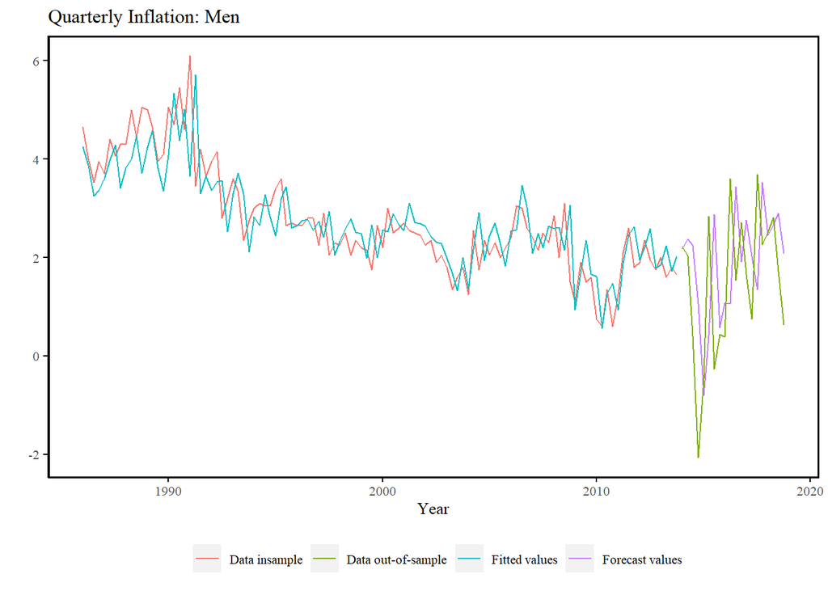

**Root mean squared error** of forecast is

```
## [1] 0.4359383
```

#### Women

**Parameter Estimate**

```
##
## Call:
## tslm(formula = form, data = data)
##
## Residuals:
##      Min       1Q   Median       3Q      Max
## -2.28952 -0.38174  0.03385  0.35974  2.42234
##
## Coefficients:
##             Estimate Std. Error t value Pr(>|t|)
## (Intercept)  1.09805    0.29296   3.748 0.000287 ***
## qPCPIXB1     0.73978    0.04881  15.155  < 2e-16 ***
## qWomen      -0.07804    0.04918  -1.587 0.115404
## ---
## Signif. codes:  0 '***' 0.001 '**' 0.01 '*' 0.05 '.' 0.1 ' ' 1
##
## Residual standard error: 0.6171 on 109 degrees of freedom
## Multiple R-squared:  0.6909, Adjusted R-squared:  0.6852
## F-statistic: 121.8 on 2 and 109 DF,  p-value: < 2.2e-16
```

Similarly, for women the slope of the Phillips curve is insignificant.

**Actual vs Fitted values and Forecast**

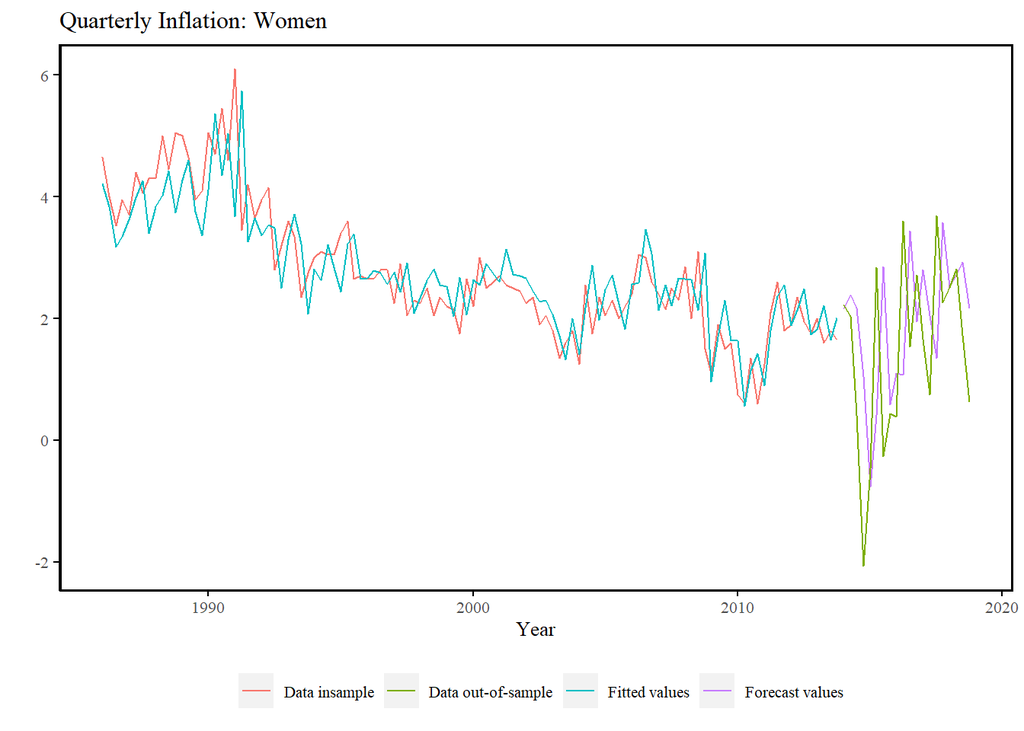

**Root mean squared error** of forecast is

```
## [1] 0.4552105
```